# Peramalan Harga Adjusted Closing IHSG Periode Januari 2017 - 31 Maret 2022

Kelompok 14 - MPDW Genap 21/22

## Anggota Kelompok

- G14190007 Dhiffa Fatihah Umami
- G14190026 Nenden Maulidia
- G14190043 Tony Alfan
- G14190047 Alvin Christian
- G14190071 Muhammad Hadyan Rizki

# Praproses Data

## Import Library dan Dataset

Mengimport libraries yang akan digunakan

```r
library(knitr)
library(imputeTS)
library(quantmod)
library(aTSA)
library(TSA)
library(forecast)
library(tseries)
library(MASS)
library(lmtest)
```

Import data dan melihat 10 data pertama.

```r
start <- as.POSIXct("2017-01-01")
end <- as.POSIXct("2022-03-31")
getSymbols(Symbols = "^JKSE",src = "yahoo", from = start, to = end)
```

```
## [1] "^JKSE"
```

```r
data <- as.data.frame(JKSE)
data$Date <- as.Date(rownames(data))
fulldates <- data.frame(Date=seq(as.Date("2017-01-01"), as.Date("2022-03-31"), by="days"))
ihsg <- merge(fulldates,data,by="Date",all.x=T)

kable(head(ihsg,10), caption="10 baris pertama Harga harian IHSG")
```

10 baris pertama Harga harian IHSG

| Date | JKSE.Open | JKSE.High | JKSE.Low | JKSE.Close | JKSE.Volume | JKSE.Adjusted |
| --- | --- | --- | --- | --- | --- | --- |
| 2017-01-01 | NA | NA | NA | NA | NA | NA |
| 2017-01-02 | NA | NA | NA | NA | NA | NA |
| 2017-01-03 | 5290.388 | 5292.181 | 5246.852 | 5275.971 | 33217000 | 5275.971 |
| 2017-01-04 | 5270.016 | 5312.956 | 5249.234 | 5301.183 | 53111300 | 5301.183 |
| 2017-01-05 | 5302.633 | 5328.490 | 5302.633 | 5325.504 | 77219400 | 5325.504 |
| 2017-01-06 | 5321.745 | 5350.245 | 5318.385 | 5347.022 | 71615300 | 5347.022 |
| 2017-01-07 | NA | NA | NA | NA | NA | NA |
| 2017-01-08 | NA | NA | NA | NA | NA | NA |
| 2017-01-09 | 5350.880 | 5360.061 | 5307.585 | 5316.364 | 97010200 | 5316.364 |
| 2017-01-10 | 5330.015 | 5331.133 | 5292.063 | 5309.924 | 70792500 | 5309.924 |

## Imputasi Missing Values

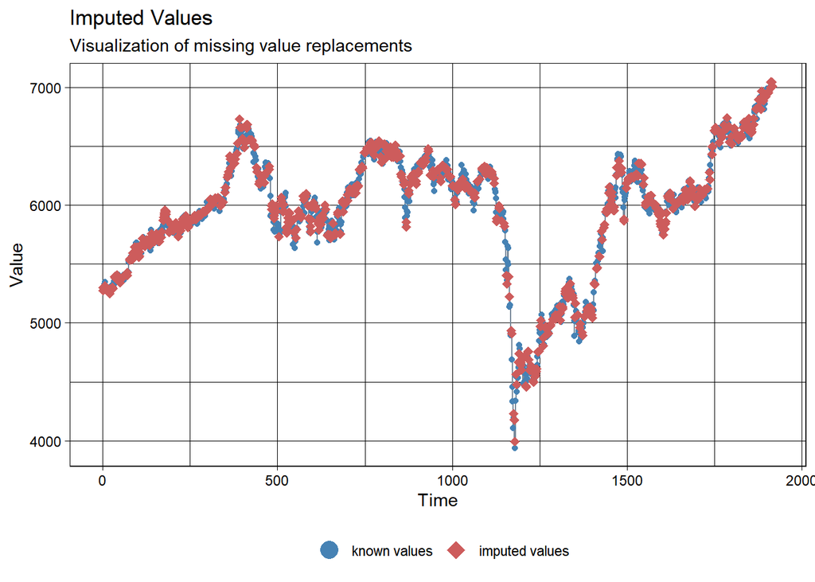

```r
ihsg.imputed <- na_interpolation(ihsg, option="spline")
ggplot_na_imputations(ihsg$JKSE.Adjusted, ihsg.imputed$JKSE.Adjusted)
```

## Split Data

Membagi data menjadi data training dan testing dengan proporsi 80% training dan 20% testing.

```r
ihsg.ts <- ts(ihsg.imputed$JKSE.Adjusted)
ihsg.seasonal <- ts(ihsg.imputed$JKSE.Adjusted, frequency=7)
train.prop <- floor(nrow(ihsg.imputed)*0.8)
test.prop <- nrow(ihsg.imputed)-train.prop

ihsg.train <- head(ihsg.ts, train.prop)
ihsg.test <- tail(ihsg.ts, test.prop)
seasonal.train <- head(ihsg.seasonal, train.prop)
seasonal.test <- tail(ihsg.seasonal, test.prop)
```

# Cek Stasioneritas Data

## Plot Deret Waktu

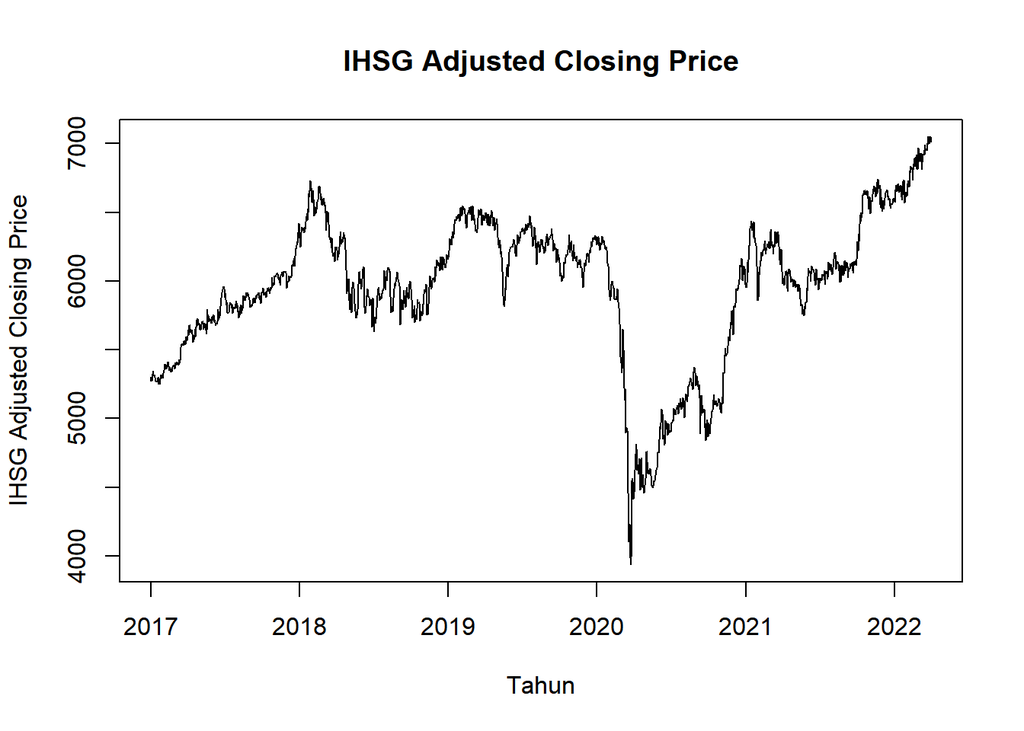

```r
plot(ihsg.imputed$JKSE.Adjusted~ihsg.imputed$Date,
     type = "l", xlab = "Tahun", main = "IHSG Adjusted Closing Price",
     ylab = "IHSG Adjusted Closing Price")
```

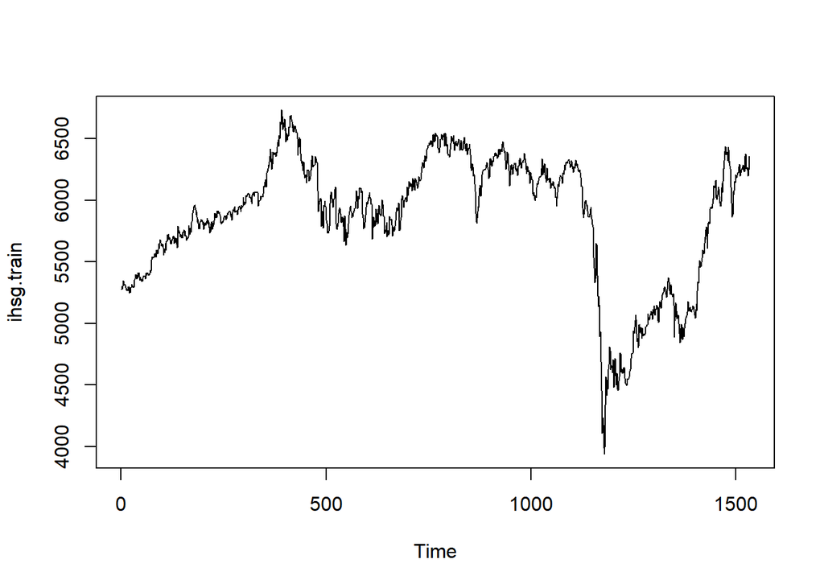

```r
ts.plot(ihsg.train)
```

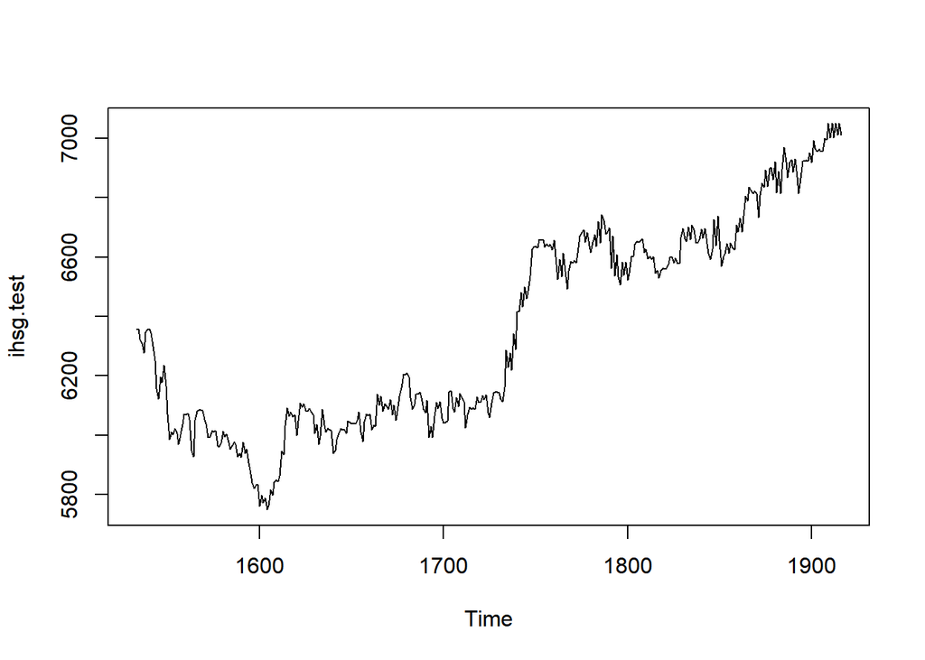

```r
ts.plot(ihsg.test)
```

Terlihat dengan cukup jelas bahwa data yang kita miliki tidak stasioner dalam ragam dan dalam rataan. Perlu dilihat plot ACF/PACF untuk mendukung dugaan tersebut.

## Plot ACF dan PACF

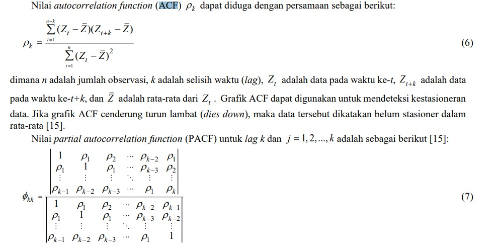

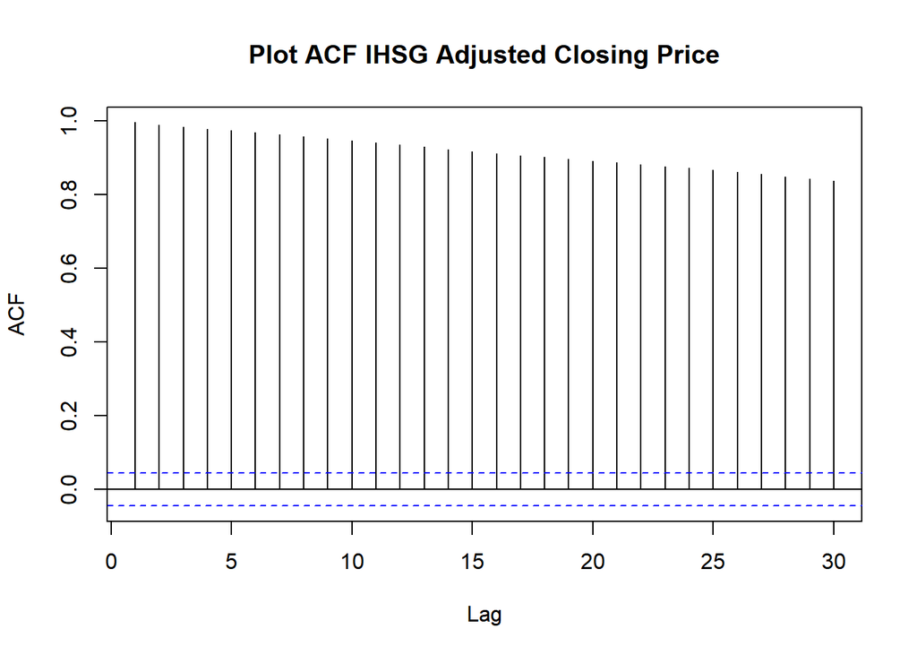

```r
acf(ihsg.ts, lag.max = 30 ,main = "Plot ACF IHSG Adjusted Closing Price")
```

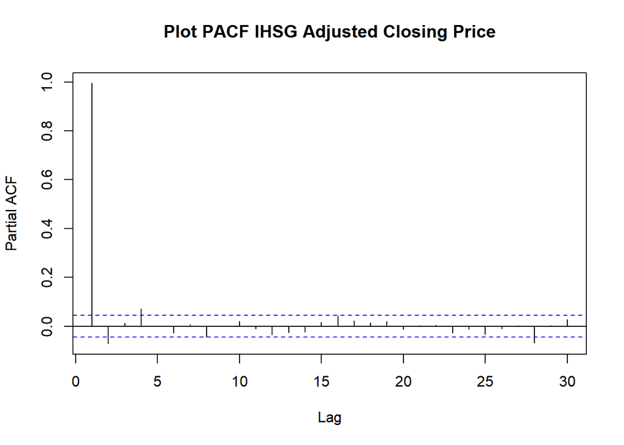

```r
pacf(ihsg.ts, lag.max = 30, main = "Plot PACF IHSG Adjusted Closing Price")
```

Plot ACF menurun secara eksponensial dan PACF cutoff di lag ke-1. Hal ini menunjukkan bahwa data kita memang tidak stasioner. Akan dikonfirmasi dengan uji formal Augmented Dickey-Fuller Test.

Menurut Stephani (2015), Kestasioneran suatu data diperlukan sebagai asumsi yang harus dipenuhi dalam analisis deret waktu. Stasioneritas memiliki arti bahwa tidak terdapat kenaikan atau penurunan pada data (data berfluktuasi di sekitaran nilai rata-rata yang konstan, tidak tergantung pada waktu dan varians dari fluktuasi tersebut dan tetap konstan setiap waktu).

Uji Augmented Dickey Fuller atau disebut juga Uji Akar Unit (Unit Root Test) merupakan uji yang dilakukan untuk mengetahui data yang diamati merupakan data deret waktu stasioner atau tidak. Data stasioner merupakan data deret waktu yang tidak mengandung akar-akar unit.

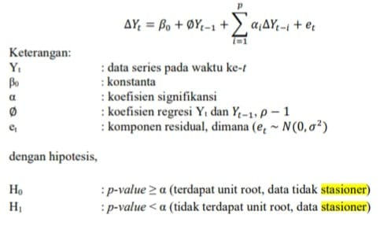

Setelah dilakukan pengujian, didapatkan nilai p-value yang kemudian dilakukan evaluasi menggunakan hipotesis diatas untuk menyatakan bahwa Yt bersifat stasioner atau tidak stasioner (Rohmawati dan Wulandari 2020).

```r
adf.test(ihsg.ts)
```

```
##
##  Augmented Dickey-Fuller Test
##
## data:  ihsg.ts
## Dickey-Fuller = -1.935, Lag order = 12, p-value = 0.6058
## alternative hypothesis: stationary
```

Berdasarkan hasil eksplorasi dan uji ADF, cukup bukti menunjukkan bahwa data belum stasioner sehingga akan dicoba dilakukan differencing 1 kali.

Differencing merupakan metode untuk menangani terjadinya ketidakstasioneran data deret waktu pada nilai rataan. Differencing dilakukan dengan menghitung perubahan atau selisih nilai observasi yang nantinya perlu untuk dilakukan pengecekan ulang stasioneritas pada data differencing pertama (Hendrawan 2012). Jika hasil differencing pertama masih belum stasioner, maka akan dilakukan differencing lagi.

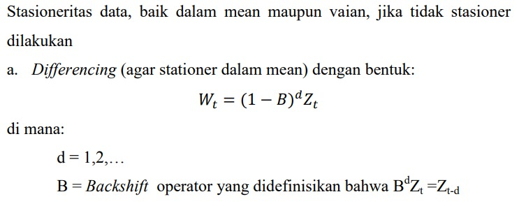

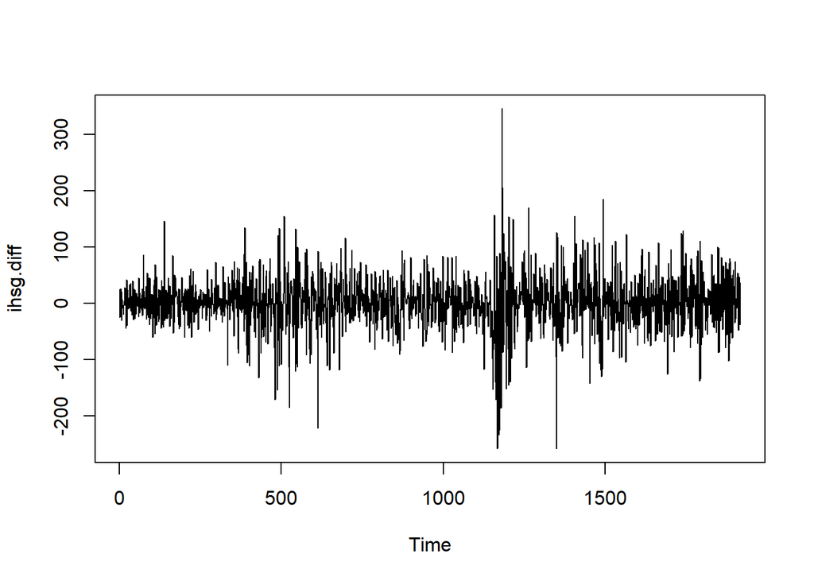

```r
ihsg.diff <- diff(ihsg.ts, differences = 1)
ts.plot(ihsg.diff)
```

Berdasarkan plot time series terlihat bahwa data sudah stasioner dalam rataan, namun dapat kita lihat bahwa terdapat perbedaan keragaman yang cukup besar dalam periode data ke-1000 hingga 1500.

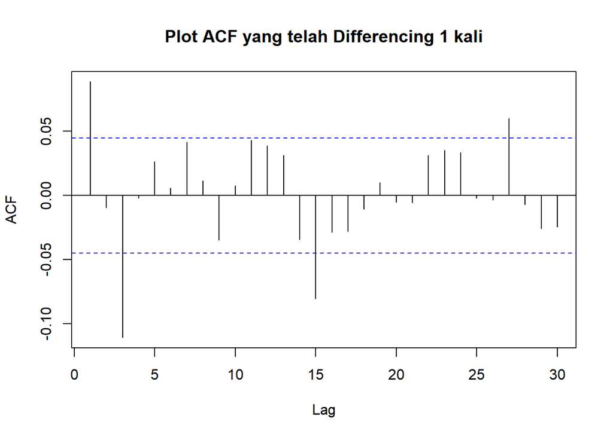

```r
acf(ihsg.diff, lag.max = 30, main = "Plot ACF yang telah Differencing 1 kali")
```

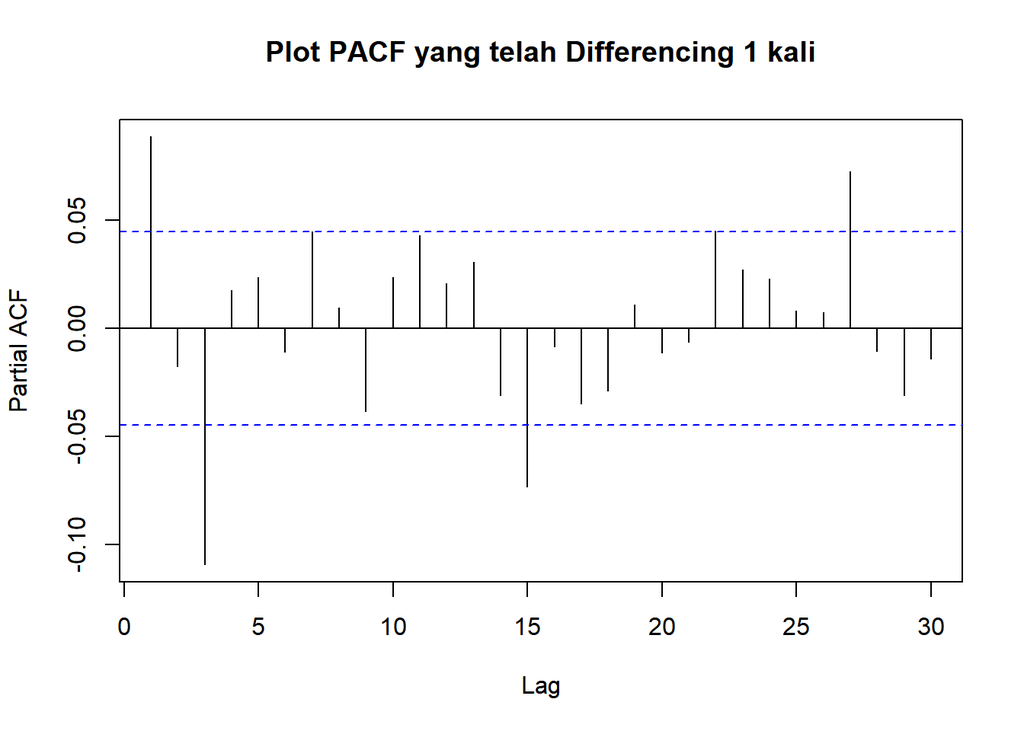

```r
pacf(ihsg.diff, lag.max = 30, main = "Plot PACF yang telah Differencing 1 kali")
```

```r
adf.test(ihsg.diff)
```

```
##
##  Augmented Dickey-Fuller Test
##
## data:  ihsg.diff
## Dickey-Fuller = -10.925, Lag order = 12, p-value = 0.01
## alternative hypothesis: stationary
```

Plot ACF/PACF dan Hasil uji ADF menunjukkan bahwa data telah stasioner sehingga dapat dilanjutkan ke tahap pemodelan. Akan dilakukan eksplorasi untuk menentukan ordo ARIMA

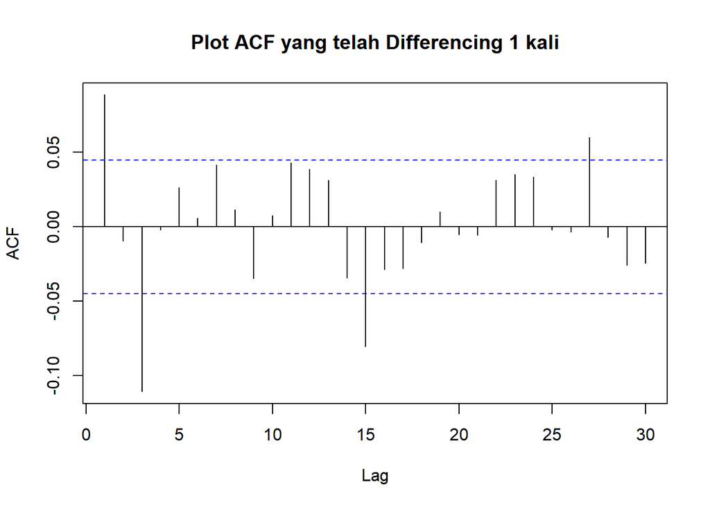

```r
acf(ihsg.diff, lag.max = 30, main = "Plot ACF yang telah Differencing 1 kali")
```

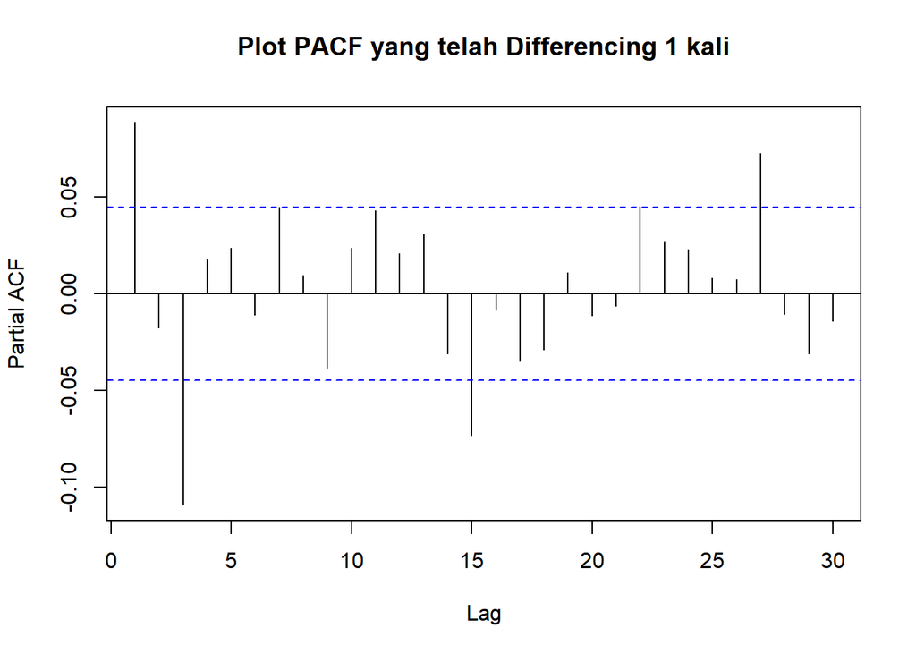

```r
pacf(ihsg.diff, lag.max = 30, main = "Plot PACF yang telah Differencing 1 kali")
```

```r
eacf(ihsg.diff)
```

```
## AR/MA
##   0 1 2 3 4 5 6 7 8 9 10 11 12 13
## 0 x o x o o o o o o o o  o  o  o
## 1 x o x o o o o o o o o  o  o  o
## 2 x x x o x o o o o o o  o  o  o
## 3 x x o o x o o o o o o  o  o  o
## 4 x x o x o o o o o o o  o  o  o
## 5 x x x x o o o o o o o  o  o  o
## 6 x x x x x o o o o o o  o  o  o
## 7 x x x x x o x o o o o  o  o  o
```

Kedua plot ACF dan PACF menunjukkan cutoff pada lag ke-1 atau ke-3. Berdasarkan plot ACF kita dapat mendapatkan calon model ARIMA(0,1,1) dan berdasarkan EACF kita dapat menemukan calon model ARIMA(0,1,3), ARIMA(0,1,4), dan ARIMA(1,1,4).

# Pemodelan ARIMA

Akan dilakukan pemodel ARIMA dengan beberapa calon model yang didapat di bagian sebelumnya dan dibandingkan dengan menggunakan AIC.

Auto Regressive Integrated Moving Average (ARIMA) merupakan metode pemodelan pada data deret waktu yang menggunakan data masa lalu dan sekarang dari variabel dependen untuk menghasilkan peramalan jangka pendek (Hendrawan 2012).

Akaike’s Information Criterion (AIC)merupakan suatu metode identifikasi model terbaik yang pertama kali diperkenalkan oleh Akaike. Suatu model dikatakn terbaik jika memiliki nilai AIC terkecil dibandingkan dengan nilai AIC yang lainnya (Maswar 2017).. Akaike Information Criterion (AIC) merupakan salah satu metode yang umum digunakan untuk menghitung panjang lag. Dimana jika panjang lag yang digunakan terlalu kecil akan membuat model tidak dapat digunakan karena kurang mampu menjelaskan hubungannya, namun jika panjang lag yang digunakan terlalu besar maka akan menghasilkan estimasi yang kurang efisien karena berkurangnya degree of freedom.

Akaike Information Criterion (AIC) dirumuskan dalam persamaan berikut:

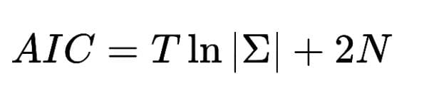

Dimana |Σ| adalah determinan matriks residual varians atau kovarian dan N adalah jumlah total dari parameter yang diestimasi (Rohmawati dan Wulandari 2020)

```r
ihsg.model1 <- Arima(ihsg.ts, order=c(0,1,3), method="ML")
ihsg.model2 <- Arima(ihsg.ts, order=c(0,1,4), method="ML")
ihsg.model3 <- Arima(ihsg.ts, order=c(1,1,4), method="ML")
ihsg.model4 <- Arima(ihsg.ts, order=c(0,1,1), method="ML")
ihsg.model1$aic; ihsg.model2$aic; ihsg.model3$aic; ihsg.model4$aic
```

```
## [1] 20089.87
```

```
## [1] 20091.86
```

```
## [1] 20093.85
```

```
## [1] 20110.36
```

Kemudian akan diperiksa tiap model apakah sudah signifikan

```r
coeftest(ihsg.model1)
```

```
##
## z test of coefficients:
##
##       Estimate Std. Error z value  Pr(>|z|)
## ma1  0.0910281  0.0226084  4.0263 5.666e-05 ***
## ma2  0.0081053  0.0226280  0.3582    0.7202
## ma3 -0.1142979  0.0230682 -4.9548 7.241e-07 ***
## ---
## Signif. codes:  0 '***' 0.001 '**' 0.01 '*' 0.05 '.' 0.1 ' ' 1
```

```r
coeftest(ihsg.model2)
```

```
##
## z test of coefficients:
##
##       Estimate Std. Error z value  Pr(>|z|)
## ma1  0.0906499  0.0229824  3.9443 8.002e-05 ***
## ma2  0.0081617  0.0226930  0.3597    0.7191
## ma3 -0.1142650  0.0230700 -4.9530 7.309e-07 ***
## ma4  0.0021857  0.0222911  0.0981    0.9219
## ---
## Signif. codes:  0 '***' 0.001 '**' 0.01 '*' 0.05 '.' 0.1 ' ' 1
```

```r
coeftest(ihsg.model3)
```

```
##
## z test of coefficients:
##
##       Estimate Std. Error z value  Pr(>|z|)
## ar1  0.0457796        NaN     NaN       NaN
## ma1  0.0446320        NaN     NaN       NaN
## ma2  0.0040532        NaN     NaN       NaN
## ma3 -0.1146450  0.0222528 -5.1519 2.578e-07 ***
## ma4  0.0087977        NaN     NaN       NaN
## ---
## Signif. codes:  0 '***' 0.001 '**' 0.01 '*' 0.05 '.' 0.1 ' ' 1
```

```r
coeftest(ihsg.model4)
```

```
##
## z test of coefficients:
##
##     Estimate Std. Error z value  Pr(>|z|)
## ma1 0.088547   0.022321  3.9669 7.281e-05 ***
## ---
## Signif. codes:  0 '***' 0.001 '**' 0.01 '*' 0.05 '.' 0.1 ' ' 1
```

Terlihat bahwa seluruh parameter pada model 4 yaitu ARIMA(0,1,1) sudah signifikan sedangkan model 1, 2, dan 3 hanya sebagian yang signifikan.

# Uji Diagnostik

Uji diagnostik dilakukan untuk mengecek apakah model yang dipilih sesuai dengan data secara baik (Rais 2009). Menurut Maswar (2017), pemeriksaan diagnosis (diagnosacheking) dilakukan untuk membuktikan bahwa model tersebut memadai (valid). Dalam pemeriksaan diagnosis ini, dilakukan uji asumsi-asumsi pemodelan, antara lain:

```r
ihsg.residual1 <- ihsg.model1$residuals
ihsg.residual2 <- ihsg.model2$residuals
ihsg.residual3 <- ihsg.model3$residuals
ihsg.residual4 <- ihsg.model4$residuals
```

## Normalitas

Uji normalitas residual dilakukan untuk mengetahui kenormalan nilai residual data. Suatu model data dikatakan baik apabila residual data berdistribusi normal. Normalitas residual terjadi apabila histogram residual mempunyai kecenderungan membentuk pola lonceng.

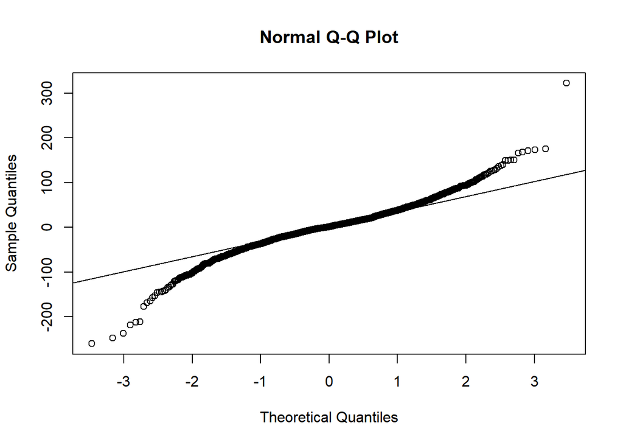

```r
qqnorm(ihsg.residual1)
qqline(ihsg.residual1)
```

```r
jarque.bera.test(ihsg.residual1)
```

```
##
##  Jarque Bera Test
##
## data:  ihsg.residual1
## X-squared = 1455.4, df = 2, p-value < 2.2e-16
```

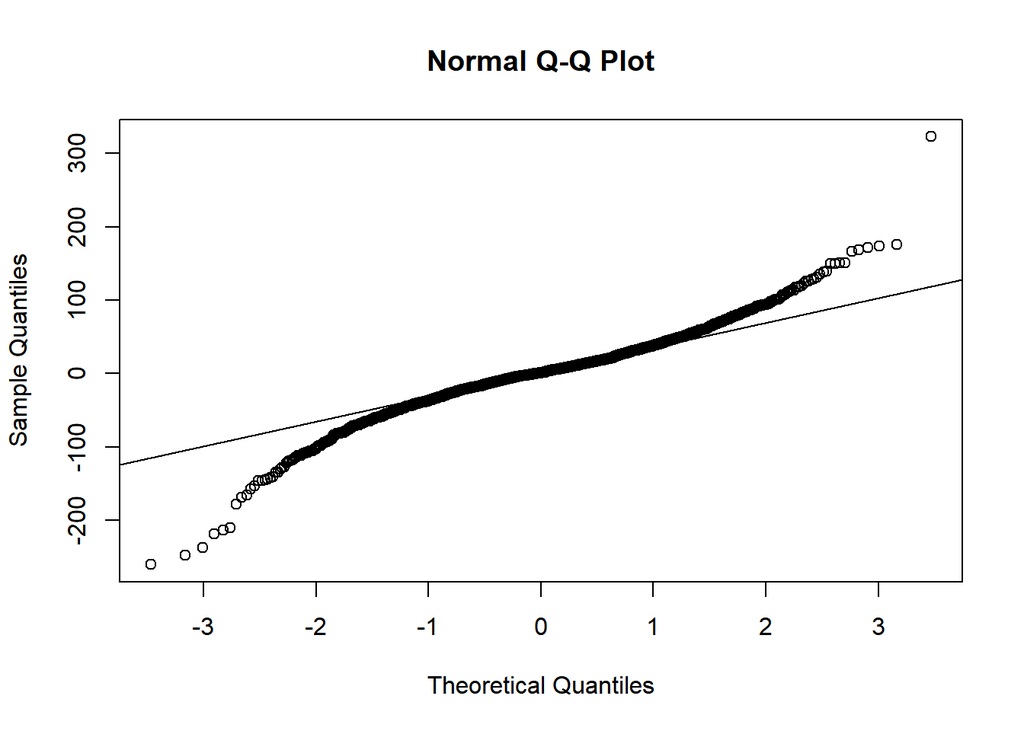

```r
qqnorm(ihsg.residual2)
qqline(ihsg.residual2)
```

```r
jarque.bera.test(ihsg.residual2)
```

```
##
##  Jarque Bera Test
##
## data:  ihsg.residual2
## X-squared = 1454.6, df = 2, p-value < 2.2e-16
```

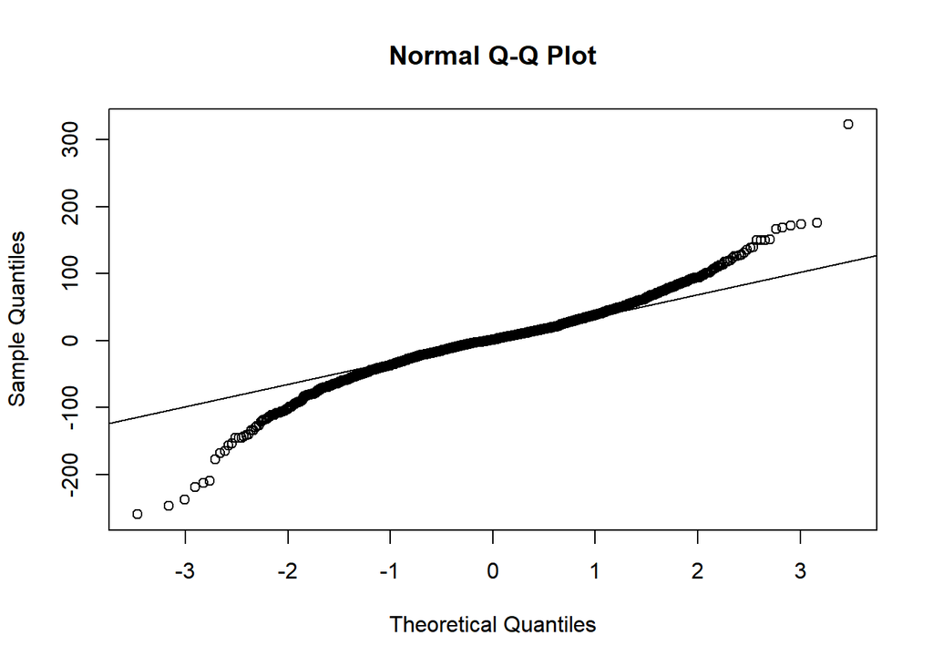

```r
qqnorm(ihsg.residual3)
qqline(ihsg.residual3)
```

```r
jarque.bera.test(ihsg.residual3)
```

```
##
##  Jarque Bera Test
##
## data:  ihsg.residual3
## X-squared = 1453.9, df = 2, p-value < 2.2e-16
```

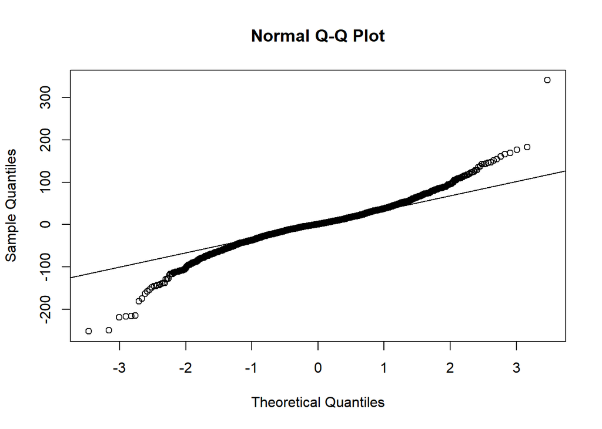

```r
qqnorm(ihsg.residual4)
qqline(ihsg.residual4)
```

```r
jarque.bera.test(ihsg.residual4)
```

```
##
##  Jarque Bera Test
##
## data:  ihsg.residual4
## X-squared = 1544.1, df = 2, p-value < 2.2e-16
```

Berdasarkan qq-plot dan uji formal Jarque Bera, sisaan keempat model cenderung tidak menyebar normal sehingga asumsi normalitas tidak terpenuhi bagi keempat model.

## Kehomogenan Ragam

Uji ini dilakukan dengan tujuan untuk mengetahui apakah data mengandung heteroskedastisitas atau tidak (varians residual homogen atau tidak). Hal ini dapat diketahui melalui correlogram of residual squared. Jika correlogram tersebut menunjukkan adanya plot ACF dan PACF yang signifikan pada lag-lag pertama maka varians residual tidak konstan. Jika sebaliknya maka varians residul konstan.

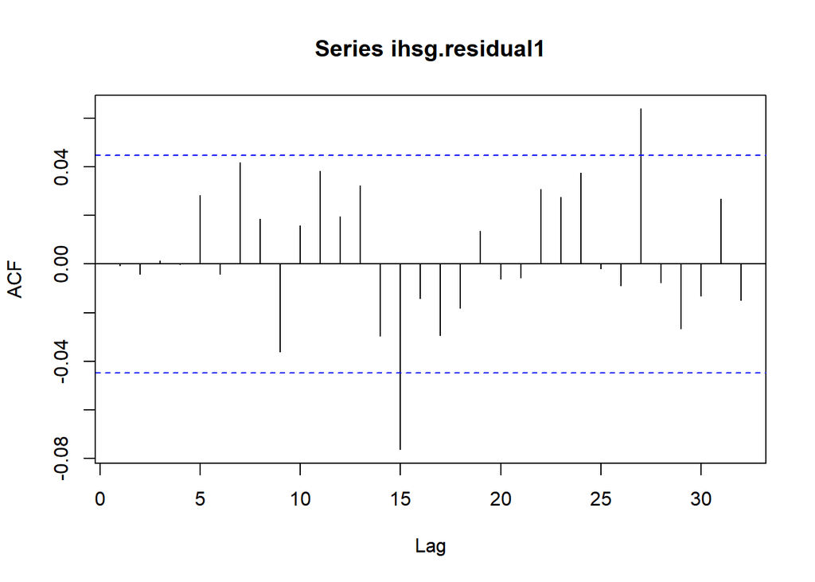

```r
acf(ihsg.residual1)
```

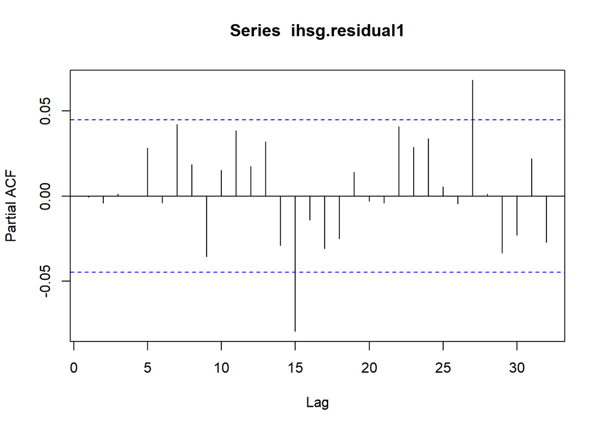

```r
pacf(ihsg.residual1)
```

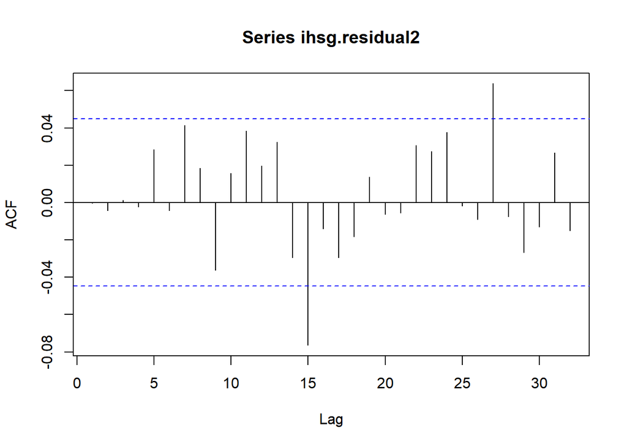

```r
acf(ihsg.residual2)
```

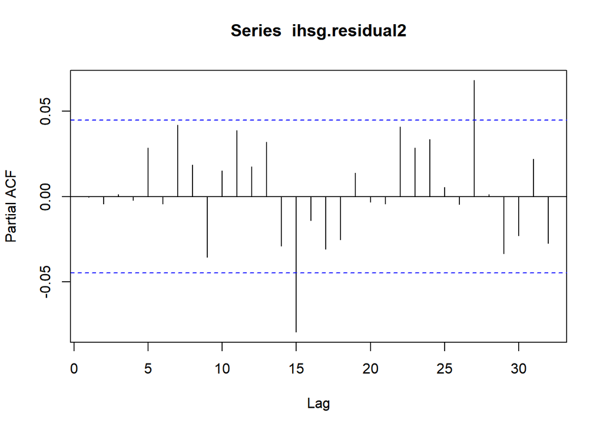

```r
pacf(ihsg.residual2)
```

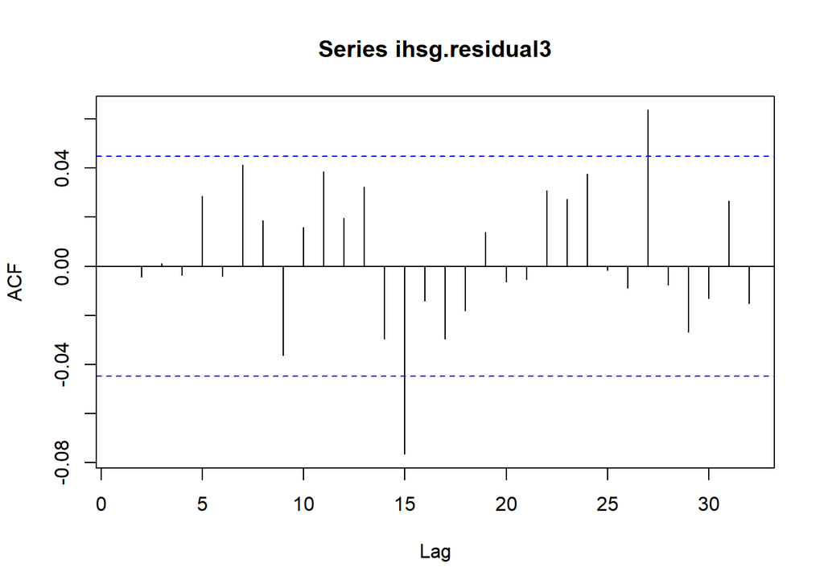

```r
acf(ihsg.residual3)
```

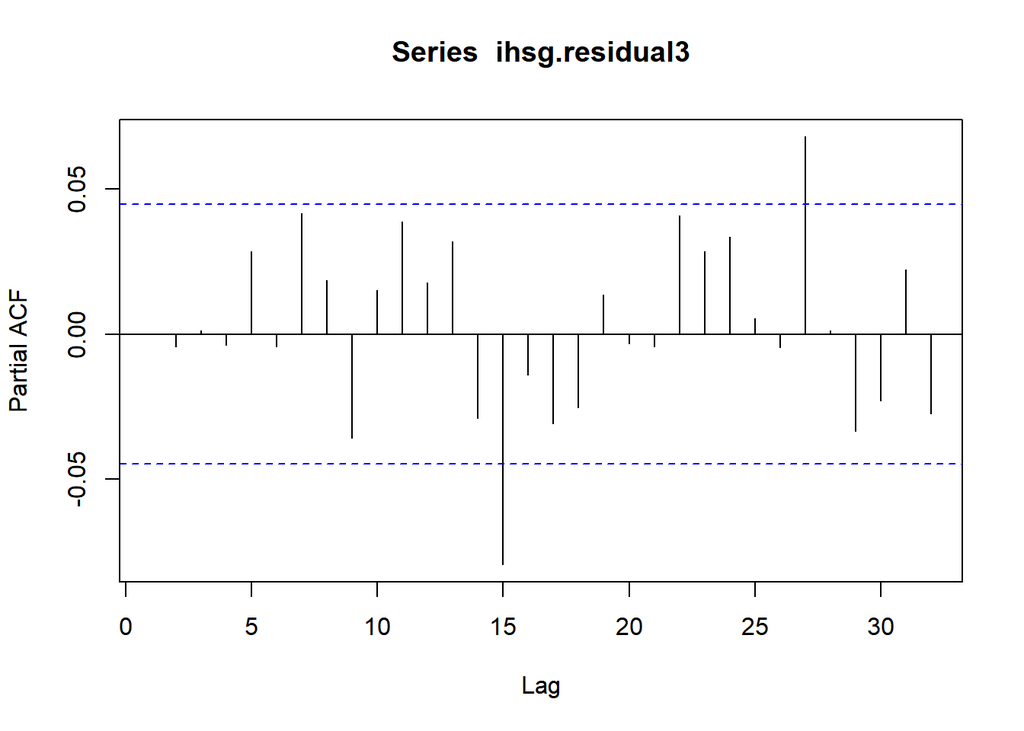

```r
pacf(ihsg.residual3)
```

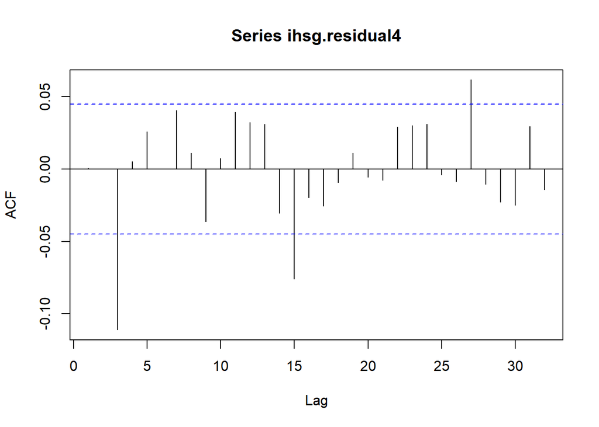

```r
acf(ihsg.residual4)
```

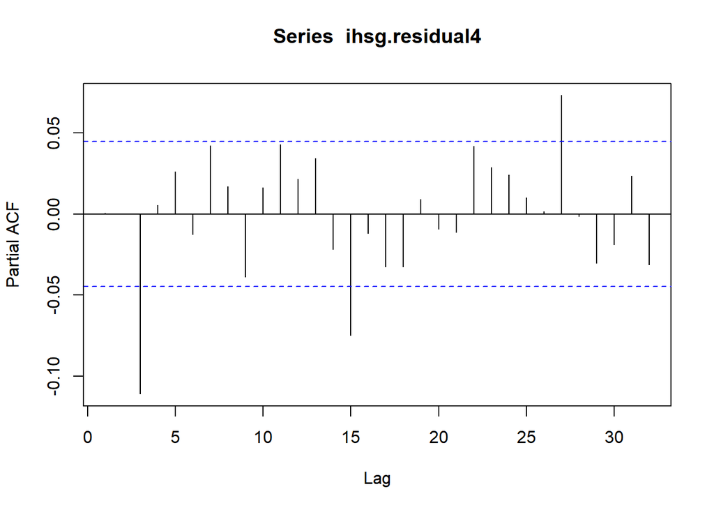

```r
pacf(ihsg.residual4)
```

## Autokorelasi

```r
Box.test(ihsg.residual1, type="Ljung")
```

```
##
##  Box-Ljung test
##
## data:  ihsg.residual1
## X-squared = 0.0006782, df = 1, p-value = 0.9792
```

```r
Box.test(ihsg.residual2, type="Ljung")
```

```
##
##  Box-Ljung test
##
## data:  ihsg.residual2
## X-squared = 0.00015718, df = 1, p-value = 0.99
```

```r
Box.test(ihsg.residual3, type="Ljung")
```

```
##
##  Box-Ljung test
##
## data:  ihsg.residual3
## X-squared = 1.5746e-05, df = 1, p-value = 0.9968
```

```r
Box.test(ihsg.residual4, type="Ljung")
```

```
##
##  Box-Ljung test
##
## data:  ihsg.residual4
## X-squared = 0.00083263, df = 1, p-value = 0.977
```

Berdasarkan hasil Ljung-Box test, terlihat bahwa data telah memenuhi asumsi tidak adanya autokorelasi.

# Transformasi

Karena asumsi normalitas tidak terpenuhi pada semua model, maka akan coba dilakukan transformasi BoxCox terhadap data Harga Adjusted Closing IHSG harian.

Menurut Draper dan Smith (1998) transformasi Box-Cox merupakan transformasi pangkat pada variabel respons yang dikembangkan oleh Box dan Cox, yang bertujuan untuk menormalkan data, melinearkan model regresi dan menghomogenkan varians. Transformasi Box-Cox hanya diberlakukan pada variabel respons Y yang bertanda positif. Prosedur utama yang dilakukan pada Transformasi Box-Cox adalah menduga parameter , yang dilakukan dengan mencari nilai Wt dan Vt melalui persamaan:

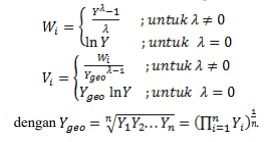

```r
bc <- boxcox(ihsg.ts ~ 1)
```

[figure not shown]

```r
(lambda <- bc$x[which.max(bc$y)])
```

```
## [1] 2
```

```r
tfed.ts <- ihsg.ts^(lambda)
train.prop <- floor(nrow(ihsg.imputed)*0.8)
test.prop <- nrow(ihsg.imputed)-train.prop

tfed.train <- head(tfed.ts, train.prop)
tfed.test <- tail(tfed.ts, test.prop)
```

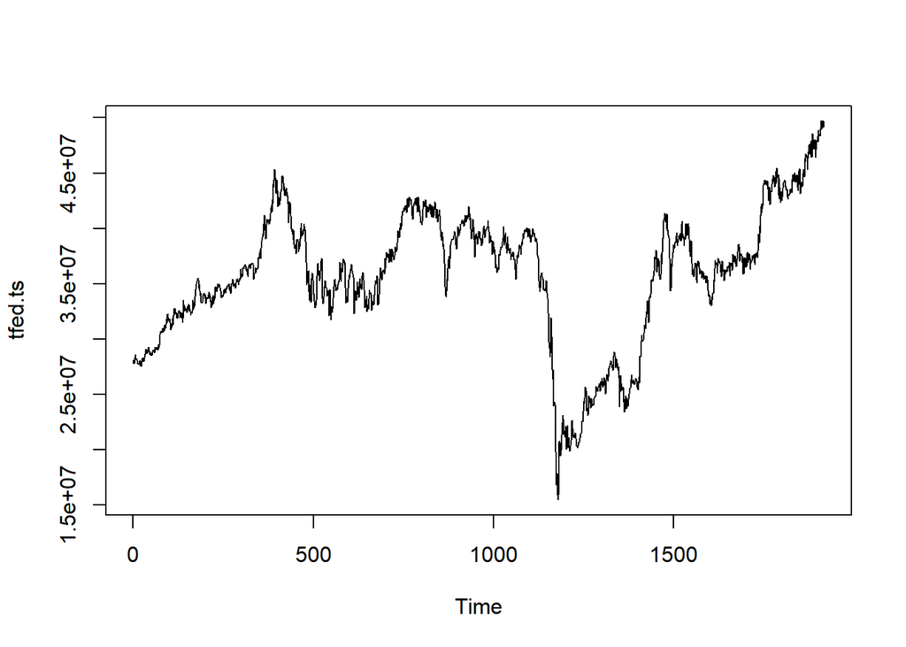

```r
ts.plot(tfed.ts)
```

Terlihat bahwa plot deret waktu dari data yang telah ditransformasi belum stasioner maka tetap perlu dilakukan differencing.

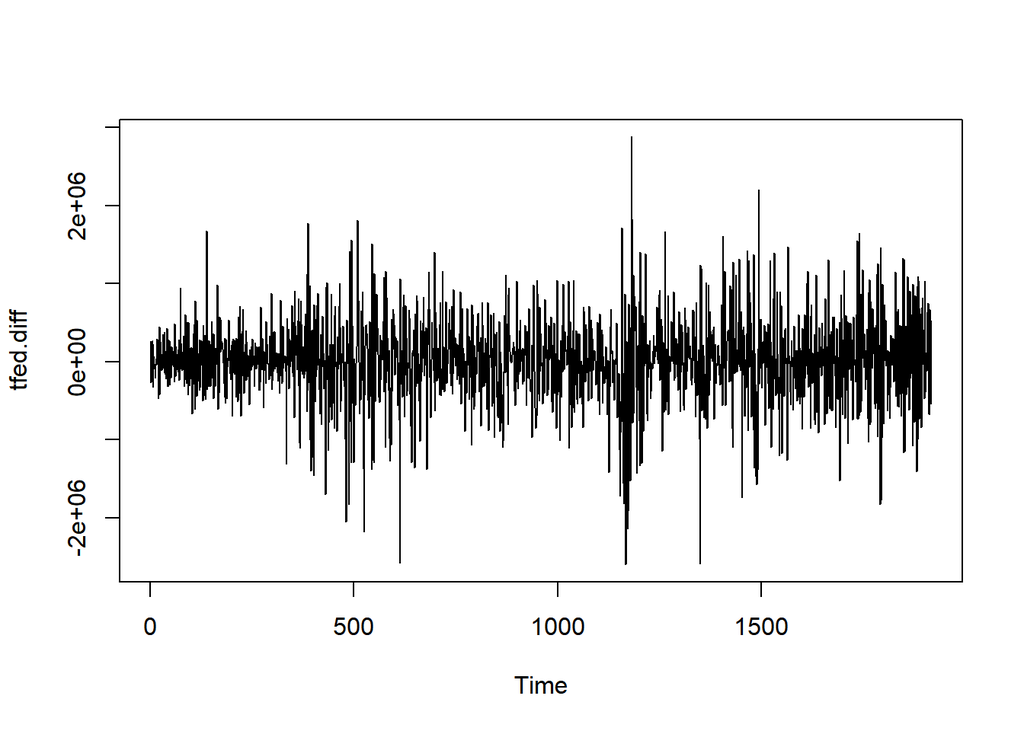

```r
tfed.diff <- diff(tfed.ts, differences=1)
ts.plot(tfed.diff)
```

```r
adf.test(tfed.diff)
```

```
##
##  Augmented Dickey-Fuller Test
##
## data:  tfed.diff
## Dickey-Fuller = -10.93, Lag order = 12, p-value = 0.01
## alternative hypothesis: stationary
```

Akan Kembali dilakukan pemodelan terhadap data yang telah ditransformasi

```r
ihsg.tfed.model1 <- Arima(tfed.ts, order=c(0,1,3), method="ML")
ihsg.tfed.model2 <- Arima(tfed.ts, order=c(0,1,4), method="ML")
ihsg.tfed.model3 <- Arima(tfed.ts, order=c(1,1,4), method="ML")
ihsg.tfed.model4 <- Arima(tfed.ts, order=c(0,1,1), method="ML")
ihsg.tfed.model1$aic; ihsg.tfed.model2$aic; ihsg.tfed.model3$aic; ihsg.tfed.model4$aic
```

```
## [1] 55928.23
```

```
## [1] 55930.23
```

```
## [1] 55932.23
```

```
## [1] 55945.92
```

Didapatkan bahwa model ARIMA(0,1,3) pada data yang telah ditransformasi tetap memiliki nilai AIC paling kecil. Akan kembali diperiksa koefisien dari tiap model.

```r
coeftest(ihsg.tfed.model1)
```

```
##
## z test of coefficients:
##
##      Estimate Std. Error z value Pr(>|z|)
## ma1  0.051543   0.022681  2.2725  0.02306 *
## ma2  0.016838   0.022616  0.7446  0.45654
## ma3 -0.106589   0.023120 -4.6103 4.02e-06 ***
## ---
## Signif. codes:  0 '***' 0.001 '**' 0.01 '*' 0.05 '.' 0.1 ' ' 1
```

```r
coeftest(ihsg.tfed.model2)
```

```
##
## z test of coefficients:
##
##        Estimate  Std. Error z value  Pr(>|z|)
## ma1  0.05146999  0.02289642  2.2479   0.02458 *
## ma2  0.01685349  0.02265548  0.7439   0.45693
## ma3 -0.10659959  0.02313843 -4.6070 4.084e-06 ***
## ma4  0.00058594  0.02244872  0.0261   0.97918
## ---
## Signif. codes:  0 '***' 0.001 '**' 0.01 '*' 0.05 '.' 0.1 ' ' 1
```

```r
coeftest(ihsg.tfed.model3)
```

```
##
## z test of coefficients:
##
##       Estimate Std. Error z value Pr(>|z|)
## ar1  0.0254016        NaN     NaN      NaN
## ma1  0.0260152        NaN     NaN      NaN
## ma2  0.0155700        NaN     NaN      NaN
## ma3 -0.1070557        NaN     NaN      NaN
## ma4  0.0036368        NaN     NaN      NaN
```

```r
coeftest(ihsg.tfed.model4)
```

```
##
## z test of coefficients:
##
##     Estimate Std. Error z value Pr(>|z|)
## ma1 0.048989   0.022313  2.1955  0.02813 *
## ---
## Signif. codes:  0 '***' 0.001 '**' 0.01 '*' 0.05 '.' 0.1 ' ' 1
```